# Multilevel analysis warm-up: sleepstudy + simulated longitudinal data

Umut Can Vural

2026-09-30

## Purpose

This document demonstrates a complete workflow for multilevel (mixed-effects) modelling and simulation-based power analysis in R. It uses the `sleepstudy` dataset as a warm-up, then simulates a 2 × 3 longitudinal intervention study (digital-skills training in older adults). The same code structure can be adapted to other repeated-measures designs and outcomes.

## Required packages

**tidyverse**: Collection of packages for data import, manipulation, and visualization (readr, dplyr, tidyr, ggplot2, etc.).

**lme4**: Fits linear mixed-effects models with random intercepts and slopes.

**lmerTest**: Extends lme4 models with Satterthwaite-approximated degrees of freedom and p-values.

**performance**: Computes model-quality indices (e.g., ICC, R²) and produces diagnostic plots.

**here**: Constructs file paths relative to the project root for portable, reproducible code.

**ggplot2**: Creates layered graphics for data visualization.

**purrr**: Provides functional programming tools (e.g., map_dfr) for iteration and simulation.

**see**: Enhances visualization of mixed models and diagnostics.

```r
library(lme4)
library(lmerTest)
library(tidyverse)
library(performance)
library(here)
library(ggplot2)
library(purrr)
library(see)
```

## 01 The sleepstudy warm-up

```r
data(sleepstudy)
glimpse(sleepstudy)
```

```
## Rows: 180
## Columns: 3
## $ Reaction <dbl> 249.5600, 258.7047, 250.8006, 321.4398, 356.8519, 414.6901, 3…
## $ Days     <dbl> 0, 1, 2, 3, 4, 5, 6, 7, 8, 9, 0, 1, 2, 3, 4, 5, 6, 7, 8, 9, 0…
## $ Subject  <fct> 308, 308, 308, 308, 308, 308, 308, 308, 308, 308, 309, 309, 3…
```

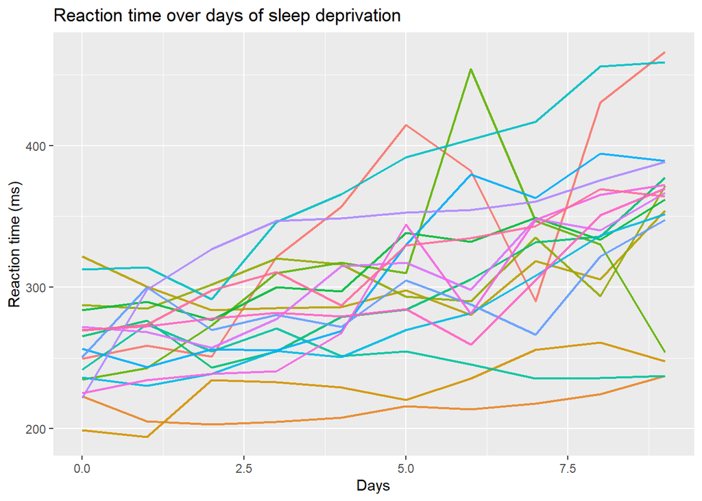

```r
# Look at the data first: one line per person
ggplot(sleepstudy, aes(Days, Reaction, group = Subject, colour = Subject)) +
  geom_line(alpha = 0.9, linewidth = 0.8) +
  labs(title = "Reaction time over days of sleep deprivation",
       x = "Days", y = "Reaction time (ms)") +
  theme(legend.position = "none")
```

```r
#before I use any predictor, how much do people differ from each other, compared with how much one person varies from measurement to measurement?
m_null <- lmer(Reaction ~ 1 + (1 | Subject), data = sleepstudy)
icc(m_null)
```

```
## # Intraclass Correlation Coefficient
##
##     Adjusted ICC: 0.395
##   Unadjusted ICC: 0.395
```

```r
# m0: ordinary regression (ignores that measurements come from the same people)
# Reaction time gets slower per day
m0 <- lm(Reaction ~ Days, data = sleepstudy)

# m1: each person has their own baseline
# Everyone starts at a different level, but everyone gets slower at the same rate.
m1 <- lmer(Reaction ~ Days + (1 | Subject), data = sleepstudy)

# m2: each person has their own baseline AND their own slope over time
# Everyone starts at a different level, and everyone gets slower at their own rate
m2 <- lmer(Reaction ~ Days + (Days | Subject), data = sleepstudy)

summary(m0)
```

```
##
## Call:
## lm(formula = Reaction ~ Days, data = sleepstudy)
##
## Residuals:
##      Min       1Q   Median       3Q      Max
## -110.848  -27.483    1.546   26.142  139.953
##
## Coefficients:
##             Estimate Std. Error t value Pr(>|t|)
## (Intercept)  251.405      6.610  38.033  < 2e-16 ***
## Days          10.467      1.238   8.454 9.89e-15 ***
## ---
## Signif. codes:  0 '***' 0.001 '**' 0.01 '*' 0.05 '.' 0.1 ' ' 1
##
## Residual standard error: 47.71 on 178 degrees of freedom
## Multiple R-squared:  0.2865, Adjusted R-squared:  0.2825
## F-statistic: 71.46 on 1 and 178 DF,  p-value: 9.894e-15
```

```r
summary(m1)
```

```
## Linear mixed model fit by REML. t-tests use Satterthwaite's method [
## lmerModLmerTest]
## Formula: Reaction ~ Days + (1 | Subject)
##    Data: sleepstudy
##
## REML criterion at convergence: 1786.5
##
## Scaled residuals:
##     Min      1Q  Median      3Q     Max
## -3.2257 -0.5529  0.0109  0.5188  4.2506
##
## Random effects:
##  Groups   Name        Variance Std.Dev.
##  Subject  (Intercept) 1378.2   37.12
##  Residual              960.5   30.99
## Number of obs: 180, groups:  Subject, 18
##
## Fixed effects:
##             Estimate Std. Error       df t value Pr(>|t|)
## (Intercept) 251.4051     9.7467  22.8102   25.79   <2e-16 ***
## Days         10.4673     0.8042 161.0000   13.02   <2e-16 ***
## ---
## Signif. codes:  0 '***' 0.001 '**' 0.01 '*' 0.05 '.' 0.1 ' ' 1
##
## Correlation of Fixed Effects:
##      (Intr)
## Days -0.371
```

```r
icc(m1)
```

```
## # Intraclass Correlation Coefficient
##
##     Adjusted ICC: 0.589
##   Unadjusted ICC: 0.424
```

```r
summary(m2)
```

```
## Linear mixed model fit by REML. t-tests use Satterthwaite's method [
## lmerModLmerTest]
## Formula: Reaction ~ Days + (Days | Subject)
##    Data: sleepstudy
##
## REML criterion at convergence: 1743.6
##
## Scaled residuals:
##     Min      1Q  Median      3Q     Max
## -3.9536 -0.4634  0.0231  0.4634  5.1793
##
## Random effects:
##  Groups   Name        Variance Std.Dev. Corr
##  Subject  (Intercept) 612.10   24.741
##           Days         35.07    5.922   0.07
##  Residual             654.94   25.592
## Number of obs: 180, groups:  Subject, 18
##
## Fixed effects:
##             Estimate Std. Error      df t value Pr(>|t|)
## (Intercept)  251.405      6.825  17.000  36.838  < 2e-16 ***
## Days          10.467      1.546  17.000   6.771 3.26e-06 ***
## ---
## Signif. codes:  0 '***' 0.001 '**' 0.01 '*' 0.05 '.' 0.1 ' ' 1
##
## Correlation of Fixed Effects:
##      (Intr)
## Days -0.138
```

```r
icc(m2)
```

```
## # Intraclass Correlation Coefficient
##
##     Adjusted ICC: 0.722
##   Unadjusted ICC: 0.521
```

```r
# Likelihood-ratio test:
# Does m2 fit enough better to justify being more complicated?
anova(m1, m2)
```

```
## Data: sleepstudy
## Models:
## m1: Reaction ~ Days + (1 | Subject)
## m2: Reaction ~ Days + (Days | Subject)
##    npar    AIC    BIC  logLik -2*log(L)  Chisq Df Pr(>Chisq)
## m1    4 1802.1 1814.8 -897.04    1794.1
## m2    6 1763.9 1783.1 -875.97    1751.9 42.139  2  7.072e-10 ***
## ---
## Signif. codes:  0 '***' 0.001 '**' 0.01 '*' 0.05 '.' 0.1 ' ' 1
```

### Model m0: ordinary regression

The average reaction time(RT) on day 0 is about **251 ms** (intercept). On average, RT gets about **10.5 ms** slower for each extra day of sleep deprivation (Days).

Individual observations scatter around the line by roughly **48 ms** (residual standard error, RSE), and the model explains about **29%** of the variance (R²).

The model assumes all 180 rows are independent, but they are 10 measurements from each of 18 people. The degrees of freedom(DoF) (**178**) are therefore too high, and the significance test is not trustworthy.

### Model m1: random intercept

The average RT on day 0 is still about **251 ms**, and the Days slope is still about **10.5 ms** per day. The standard error(St.E) of Days dropped from **1.238** to **0.804**.

People’s baseline RT differ from the average by about **37 ms** (SD of the random intercept). The scatter of one person’s measurements around their own line is about **31 ms** (residual SD).

Intraclass correlation coefficient (ICC) is **0.59** About **59%** of the variation in RT during these days is due to stable differences between people, and **41%** is variation within a person.

### Model m2: random intercept and random slope

The average slope is unchanged **10.5 ms**, but its standard error almost doubled **1.546**. In m1 we assumed everyone slows down at the same rate, which made the slope look more certain than it is. In m2, people are allowed to differ in their slopes, and the average slope is really estimated from 18 different people.

People’s baseline RT differ from the average by about **25 ms** (SD of the random intercept). The scatter of one person’s measurements around their own line is about **25.6 ms** (residual SD). People’s slopes vary around the average of **10.5 ms/day** by about **5.9 ms/day.** The correlation between a person’s baseline and their slope is essentially zero.

Intraclass correlation coefficient (ICC) is **0.72** About **72%** of the variation in RT during these days is due to stable differences between people, and **28%** is variation within a person. The between-person variance now depends on which day you look at, so the ICC changes over time.

### Null model and ICC

In the null model (no predictors, random intercept only), the intraclass correlation coefficient (ICC) is **0.40**. About **40%** of the total variance in reaction time is due to stable differences between people, and about **60%** is variation within a person. This justifies a multilevel approach.

### Model comparison

`anova(m1, m2)` is a likelihood-ratio test. It asks whether the more complex model (m2, random slopes) fits enough better than the simpler one (m1) to justify the extra parameters. AIC and BIC combine fit and complexity, and lower values are better.

Adding a random slope for Days improved the model substantially (AIC 1802.1 to 1763.9; χ²(2) = 42.1, p < .001). People differ not only in their baseline reaction time but also in how quickly they slow down, so m2 is the preferred model.

## 02 Simulate Fake Data

> Define reality → simulate participants → generate repeated measurements → visualize → fit model → check recovery → choose random-effects structure → diagnose model → later repeat for power.

We simulate data from 120 older adults who complete a Digital Skills Test Measure (DSTM) at baseline (0 months), 3 months, and 6 months. Participants are assigned to either a Control group or a Training group. The Training group plays digital games daily as part of a digital-skills intervention, whereas the Control group does not.

The research question is whether the Training group improves more over time than the Control group. The main effect of interest is therefore the time-by-group interaction.

Both groups have the same average baseline score of 40 points. The Control group improves by 0.5 points per month. The Training group improves by an additional 1.0 point per month, for a total average improvement of 1.5 points per month.

Participants differ in their initial DSTM scores (sd_intercept) and individual rates of change (sd_slope). Each observed score also includes occasion-specific measurement error (sd_resid): variation around that participant’s expected score at a specific assessment.

This is a 2 × 3 mixed design:

Between-participants factor: Group (Control vs. Training)

Within-participants factor: Time (0, 3, and 6 months)

> Mixed models are appropriate here because the three observations from the same participant are related rather than independent, and random effects model that participant-level variability.

Outcome: DSTM score

The simulated random intercepts, random slopes, and residual errors are assumed to be approximately normally distributed. This assumption is part of the data-generating model and is not an application of the central limit theorem.

Finally, we fit a linear mixed-effects model using lmer() to check whether it recovers the values used to generate the data. We will later estimate power by simulating the study many times, testing the time-by-group interaction in each simulation, and calculating the proportion of significant results. We can compare power across sample sizes such N=60, N=120 and N=200, or across different intervention-effect sizes.

```r
set.seed(2026)  # makes the "random" data identical every run

# ---- Step 1. TRUE VALUES ----
# Choose the true values (averages, differences between people, noise)
# Sample and measurement occasions
n_participants <- 120
time_months <- c(0, 3, 6)

# Fixed effects
b0 <- 40          # Mean baseline DSTM score in the Control group
b_time <- 0.5     # Mean monthly DSTM change in the Control group
b_group <- 0      # Baseline difference: Training minus Control
b_time_gr <- 1.0  # Additional monthly change in the Training group

# Random effects and residual error
sd_intercept <- 8 # Between-person SD in baseline DSTM scores
sd_slope <- 0.5   # Between-person SD in monthly change rates
sd_resid <- 3     # Within-person measurement error at each occasion

# ---- 2. LEVEL 2: one row per person ----
people <- tibble(
  participant_id = sprintf("P%03d", 1:n_participants),
  intervention   = rep(c("Control", "Training"), each = n_participants / 2),
  u0 = rnorm(n_participants, 0, sd_intercept),  # this person's baseline deviation
  u1 = rnorm(n_participants, 0, sd_slope)       # this person's slope deviation
)

# ---- 3. LEVEL 1: one row per person per time point ----
#Yij =baseline + individual baseline difference + time change + training baseline difference+training × time + noise
sim_data <- people |>
  crossing(time_months = time_months) |>        # every person gets every time point
  mutate(
    training = as.numeric(intervention == "Training"),
    digital_skills = b0 + u0 +                                  # baseline + person deviation
      (b_time + u1) * time_months +                             # person's own slope
      b_group * training +
      b_time_gr * training * time_months +                      # intervention effect on change
      rnorm(n(), 0, sd_resid)                                   # noise
  ) |>
  select(participant_id, intervention, time_months, digital_skills) |>
  arrange(participant_id, time_months)

# ---- 4. SAVE ----
write_csv(sim_data, here("data", "simulated_digital_skills_longitudinal.csv"))

# ---- 5. GLIMPSE ----

DSTM_data <- read_csv(here("data", "simulated_digital_skills_longitudinal.csv")) |>
  mutate(intervention = factor(intervention, levels = c("Control", "Training")))

# Did I get the data structure I expected?
# Check dimensions and variable types
glimpse(DSTM_data)
```

```
## Rows: 360
## Columns: 4
## $ participant_id <chr> "P001", "P001", "P001", "P002", "P002", "P002", "P003",…
## $ intervention   <fct> Control, Control, Control, Control, Control, Control, C…
## $ time_months    <dbl> 0, 3, 6, 0, 3, 6, 0, 3, 6, 0, 3, 6, 0, 3, 6, 0, 3, 6, 0…
## $ digital_skills <dbl> 44.95445, 48.85528, 56.47062, 33.56240, 36.04664, 40.69…
```

```r
# Check whether scores are missing
summary(DSTM_data$digital_skills)
```

```
##    Min. 1st Qu.  Median    Mean 3rd Qu.    Max.
##   14.76   36.18   41.76   42.63   49.08   76.07
```

```r
sum(is.na(DSTM_data$digital_skills))
```

```
## [1] 0
```

```r
# Check whether group and time exist
table(DSTM_data$intervention, useNA = "ifany")
```

```
##
##  Control Training
##      180      180
```

```r
table(DSTM_data$time_months, useNA = "ifany")
```

```
##
##   0   3   6
## 120 120 120
```

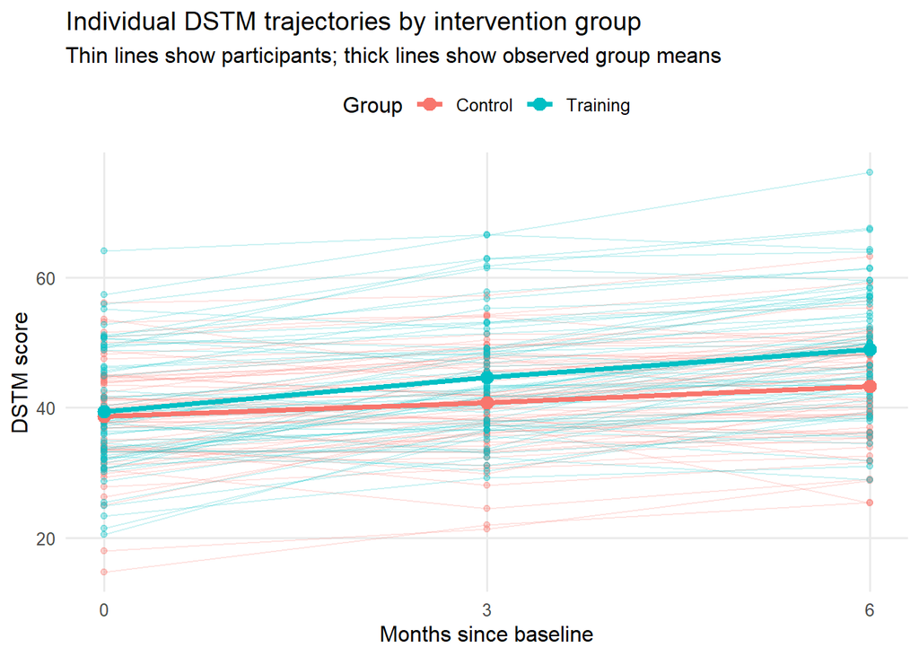

```r
# Group means at each measurement occasion
group_means <- DSTM_data %>%
  group_by(intervention, time_months) %>%
  summarise(
    mean_DSTM = mean(digital_skills),
    .groups = "drop"
  )

# Inspect the calculated group means
#group_means

# ---- 6. PLOT ----
# Does the simulated dataset visually resemble the world I intended to simulate?
ggplot(DSTM_data,
       aes(x = time_months,
           y = digital_skills,
           group = participant_id,
           colour = intervention)) +
  geom_line(alpha = 0.20, linewidth = 0.5) +
  geom_point(alpha = 0.30, size = 1.4) +
  geom_line(
    data = group_means,
    aes(x = time_months,
        y = mean_DSTM,
        group = intervention,
        colour = intervention),
    inherit.aes = FALSE,
    linewidth = 1.4
  ) +
  geom_point(
    data = group_means,
    aes(x = time_months,
        y = mean_DSTM,
        colour = intervention),
    inherit.aes = FALSE,
    size = 3
  ) +
  scale_x_continuous(breaks = c(0, 3, 6)) +
  labs(
    title = "Individual DSTM trajectories by intervention group",
    subtitle = "Thin lines show participants; thick lines show observed group means",
    x = "Months since baseline",
    y = "DSTM score",
    colour = "Group"
  ) +
  theme_minimal(base_size = 12) +
  theme(
    legend.position = "top",
    panel.grid.minor = element_blank()
  )
```

```r
# ---- 7. MODEL ----
# Each person has their own baseline and their own rate of change over time
# Estimate how large the effect of the intervention is on the rate of change over time
# 1 What's happening on average?
# 2 How much do people differ from each other?
m <- lmer(digital_skills ~ time_months * intervention + (time_months | participant_id),
          data = DSTM_data)
summary(m)
```

```
## Linear mixed model fit by REML. t-tests use Satterthwaite's method [
## lmerModLmerTest]
## Formula: digital_skills ~ time_months * intervention + (time_months |
##     participant_id)
##    Data: DSTM_data
##
## REML criterion at convergence: 2224.9
##
## Scaled residuals:
##      Min       1Q   Median       3Q      Max
## -2.47700 -0.55554 -0.02074  0.61216  2.46529
##
## Random effects:
##  Groups         Name        Variance Std.Dev. Corr
##  participant_id (Intercept) 66.19634 8.1361
##                 time_months  0.03101 0.1761   0.16
##  Residual                   10.13606 3.1837
## Number of obs: 360, groups:  participant_id, 120
##
## Fixed effects:
##                                   Estimate Std. Error        df t value
## (Intercept)                       38.63670    1.11537 117.99825  34.640
## time_months                        0.75866    0.09951 117.99253   7.624
## interventionTraining               0.94116    1.57737 117.99826   0.597
## time_months:interventionTraining   0.83251    0.14073 117.99253   5.916
##                                  Pr(>|t|)
## (Intercept)                       < 2e-16 ***
## time_months                      6.86e-12 ***
## interventionTraining                0.552
## time_months:interventionTraining 3.30e-08 ***
## ---
## Signif. codes:  0 '***' 0.001 '**' 0.01 '*' 0.05 '.' 0.1 ' ' 1
##
## Correlation of Fixed Effects:
##             (Intr) tm_mnt intrvT
## time_months -0.219
## intrvntnTrn -0.707  0.155
## tm_mnths:nT  0.155 -0.707 -0.219
```

```r
#confidence intervals for the fixed effects
#confint(m)
confint(m, parm = "beta_", method = "Wald")
```

```
##                                       2.5 %     97.5 %
## (Intercept)                      36.4506102 40.8227817
## time_months                       0.5636214  0.9536888
## interventionTraining             -2.1504272  4.0327570
## time_months:interventionTraining  0.5566929  1.1083314
```

```r
VarCorr(m)
```

```
##  Groups         Name        Std.Dev. Corr
##  participant_id (Intercept) 8.13611
##                 time_months 0.17608  0.161
##  Residual                   3.18372
```

```r
confint(m)
```

```
##                                       2.5 %     97.5 %
## .sig01                            6.9994181  9.3396142
## .sig02                            0.0000000  0.4858218
## .sig03                           -1.0000000  1.0000000
## .sigma                            2.8197688  3.5199532
## (Intercept)                      36.4502907 40.8228231
## time_months                       0.5636946  0.9536156
## interventionTraining             -2.1508794  4.0328162
## time_months:interventionTraining  0.5567963  1.1082280
```

### Random effects: truth vs estimate

$u_{0i}$: how much person $i$’s baseline differs from the average baseline.

$u_{1i}$: how much person $i$’s monthly change differs from the average monthly change.

The baseline SD (true 8) had a 95% CI of [7.0, 9.3] and the residual SD (true 3) had [2.8, 3.5], so both were recovered. The SD of individual change rates (true 0.5) had a CI of [0.00, 0.49], so it sits at the edge of what the data can detect with three waves. The intercept–slope correlation (true 0) had a CI of [-1, 1] and is not estimable here.

The degrees of freedom are about **118** because the group comparison is based mainly on **120** participants, not on all **360** observations. One simulation is only one random sample; power requires repeating the simulation many times and calculating how often the intervention-by-time effect is detected.

> Does estimating all this extra person-to-person slope variation meaningfully improve the model?

```r
# Simpler model: each person has their own baseline, but everyone shares the same rate of change
# Participants differ in baseline, but everyone has the same underlying slope after accounting for fixed effects.
m_ri <- lmer(digital_skills ~ time_months * intervention + (1 | participant_id),
             data = DSTM_data)

anova(m_ri, m)
```

```
## Data: DSTM_data
## Models:
## m_ri: digital_skills ~ time_months * intervention + (1 | participant_id)
## m: digital_skills ~ time_months * intervention + (time_months | participant_id)
##      npar    AIC    BIC  logLik -2*log(L)  Chisq Df Pr(>Chisq)
## m_ri    6 2235.7 2259.0 -1111.8    2223.7
## m       8 2239.3 2270.4 -1111.7    2223.3 0.3367  2      0.845
```

```r
summary(m_ri)$coefficients
```

```
##                                    Estimate Std. Error       df    t value
## (Intercept)                      38.6366959 1.12871204 135.5206 34.2307822
## time_months                       0.7586551 0.09819116 238.0000  7.7263080
## interventionTraining              0.9411649 1.59623987 135.5206  0.5896137
## time_months:interventionTraining  0.8325121 0.13886326 238.0000  5.9951936
##                                      Pr(>|t|)
## (Intercept)                      1.439022e-68
## time_months                      3.082266e-13
## interventionTraining             5.564314e-01
## time_months:interventionTraining 7.484828e-09
```

```r
summary(m)$coefficients
```

```
##                                    Estimate Std. Error       df    t value
## (Intercept)                      38.6366959 1.11537036 117.9983 34.6402392
## time_months                       0.7586551 0.09950881 117.9925  7.6239991
## interventionTraining              0.9411649 1.57737188 117.9983  0.5966665
## time_months:interventionTraining  0.8325121 0.14072671 117.9925  5.9158075
##                                      Pr(>|t|)
## (Intercept)                      1.129119e-63
## time_months                      6.861321e-12
## interventionTraining             5.518731e-01
## time_months:interventionTraining 3.302065e-08
```

Adding random slopes for time did not improve model fit (χ²(2) = 0.34, p = .845; AIC 2235.7 vs 2239.3). The time × group estimate and SE were nearly identical in the random-intercept and random-slope models. Because each participant has only three measurements, there is little information about individual differences in change. For simplicity and stability, we therefore use the random-intercept model (m_ri) in the power simulation.

```r
truth <- c("(Intercept)" = 40, "time_months" = 0.5,
           "interventionTraining" = 0, "time_months:interventionTraining" = 1.0)
ci <- confint(m_ri, parm = "beta_")

tibble(term = names(truth), true = truth,
       estimate = fixef(m_ri)[names(truth)],
       lower = ci[names(truth), 1], upper = ci[names(truth), 2]) |>
  mutate(covers_truth = true >= lower & true <= upper,
         across(where(is.numeric), \(x) round(x, 2))) |>
  knitr::kable()
```

| term | true | estimate | lower | upper | covers_truth |
| --- | --- | --- | --- | --- | --- |
| (Intercept) | 40.0 | 38.64 | 36.43 | 40.85 | TRUE |
| time_months | 0.5 | 0.76 | 0.57 | 0.95 | FALSE |
| interventionTraining | 0.0 | 0.94 | -2.18 | 4.07 | TRUE |
| time_months:interventionTraining | 1.0 | 0.83 | 0.56 | 1.10 | TRUE |

### Fixed effects: truth vs estimate

The time × group interaction was 0.83 points per month (95% CI [0.56, 1.1]), against a true value of 1.00.

The Control-group slope (true 0.50) was estimated at 0.76 and its interval does not contain the true value. Among several 95% intervals in one sample, an occasional miss is expected, and part of the gap is the realised group difference in random slopes. The other terms were consistent with the true values.

### Model diagnostics

> Does the fitted model behave in a way that makes its assumptions look reasonable?

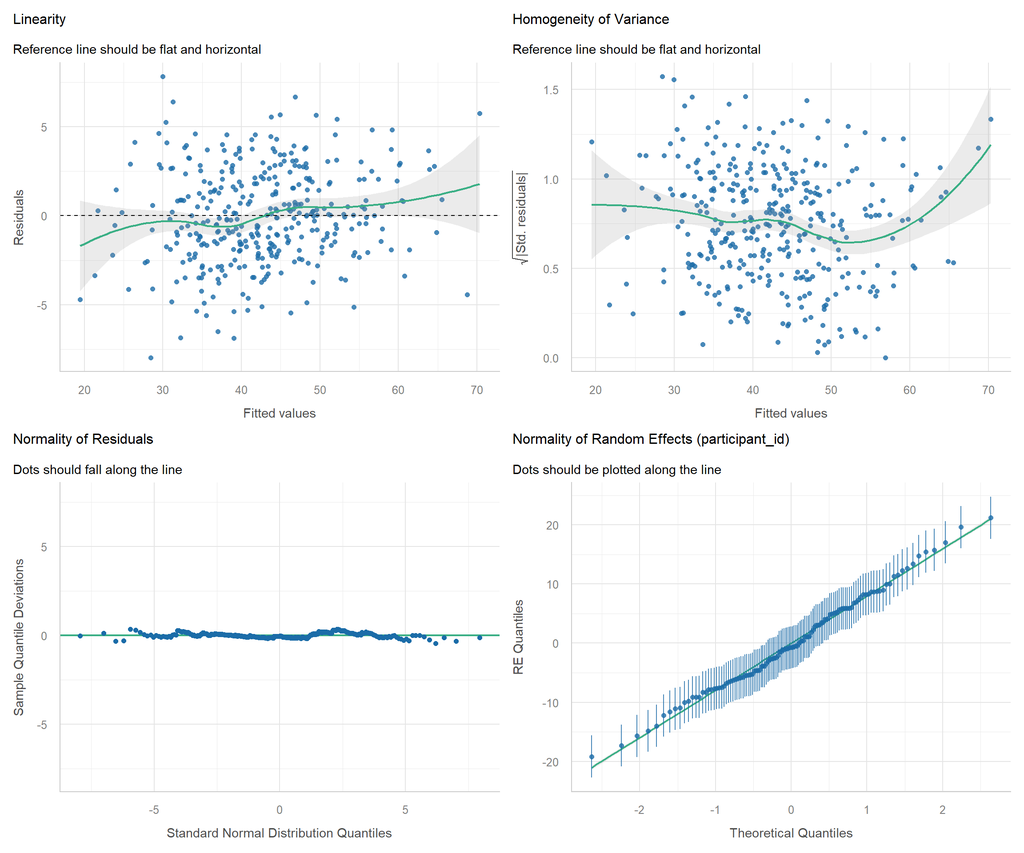

```r
performance::check_model(
  m_ri,
  check = c("qq", "linearity", "homogeneity", "reqq"),
  base_size = 11
)
```

```r
performance::check_model(
  m_ri,
  check = "outliers",
  base_size = 11
)
```

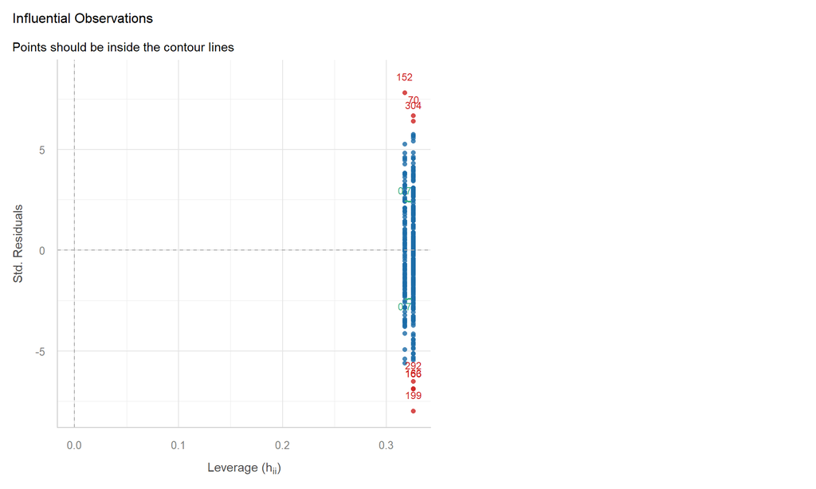

**Diagnostic guide.** Model assumptions were assessed visually using diagnostic plots. The Q-Q plots were used to assess the normality of residuals and random effects, while the linearity and homogeneity plots were inspected for systematic patterns and non-constant residual variance. Influential observations were examined separately because their observation labels are difficult to read in the combined diagnostic panel.

Residuals showed no clear pattern against fitted values, supporting linearity and homoscedasticity. Q–Q plots of residuals and random intercepts were close to the diagonal, with only minor deviations in the extremes. Most observations had low leverage and residuals (blue points), with a few moderately influential cases (70, 152, 153, 166, 199, 292, 304) appearing as red points in the tails. Because the data were simulated from a correctly specified linear mixed model with normal errors, these small deviations reflect sampling variability rather than meaningful assumption violations. Normality holds by design.

### Power Simulation

All power simulations use the random-intercept model, because adding random slopes did not improve fit and yielded nearly identical fixed-effect estimates.

```r
simulate_one <- function(
  n_participants = 120,
  time_months = c(0, 3, 6),
  b0 = 40,
  b_time = 0.5,
  b_group = 0,
  b_time_gr = 1.0,
  sd_intercept = 8,
  sd_slope = 0.5,
  sd_resid = 3,
  seed = NULL
) {

  if (!is.null(seed)) set.seed(seed)

  # Create NEW people every simulation
  people <- tibble(
    participant_id = sprintf("P%03d", 1:n_participants),
    intervention = rep(
      c("Control", "Training"),
      each = n_participants / 2
    ),
    u0 = rnorm(n_participants, 0, sd_intercept),
    u1 = rnorm(n_participants, 0, sd_slope)
  )

  # Create NEW observations every simulation
  sim_data <- people |>
    tidyr::crossing(time_months = time_months) |>
    mutate(
      training = as.numeric(intervention == "Training"),

      digital_skills =
        b0 + u0 +
        (b_time + u1) * time_months +
        b_group * training +
        b_time_gr * training * time_months +
        rnorm(n(), 0, sd_resid)
    )

  DSTM_data <- sim_data |>
    mutate(
      participant_id = factor(participant_id),
      intervention = factor(
        intervention,
        levels = c("Control", "Training")
      )
    )

  # Fit model
  m <- lmerTest::lmer(
    digital_skills ~ time_months * intervention +
      (1 | participant_id),
    data = DSTM_data
  )

  co <- coef(summary(m))

  int_idx <- which(
    rownames(co) == "time_months:interventionTraining"
  )

  tibble(
    n_participants = n_participants,
    b_time_gr_true = b_time_gr,
    estimate = co[int_idx, "Estimate"],
    SE = co[int_idx, "Std. Error"],
    t_value = co[int_idx, "t value"],
    p_value = co[int_idx, "Pr(>|t|)"]
  )
}
```

### Effect Size

> What power would my study have under each of these possible realities?

We can change the true effect size of the intervention on the rate of change (b_time_gr) and the number of participants (n_participants) to see how power changes. The following code sets up a grid of different sample sizes and effect sizes, simulates data for each combination, and calculates the power for detecting the time-by-intervention interaction.

```r
n_vals      <- c(60, 120, 200)
effect_vals <- c(0.25, 0.5, 1.0, 1.5, 0) # 0 as false positive control expect 5%

grid <- expand.grid(n_participants = n_vals, b_time_gr = effect_vals)

power_file <- here("results", "power_grid.rds")

if (file.exists(power_file)) {
  power_grid <- readRDS(power_file)
} else {
  power_grid <- map_dfr(seq_len(nrow(grid)), function(i) {
    row  <- grid[i, ]
    sims <- map_dfr(1:1000, ~ simulate_one(
      n_participants = row$n_participants,
      b_time_gr      = row$b_time_gr,
      seed           = 3000 + i * 1000 + .x))
    tibble(n_participants  = row$n_participants,
           b_time_gr_true  = row$b_time_gr,
           power           = mean(sims$p_value < 0.05, na.rm = TRUE))
  })
  dir.create(here("results"), showWarnings = FALSE)
  saveRDS(power_grid, power_file)
}
```

**Power simulation.** Estimated power increased with both sample size and the magnitude of the time-by-group interaction. For a small interaction of 0.25 points/month, estimated power increased from 24.3% at N = 60 to 61.5% at N = 200 and remained below 80% across the examined sample sizes. For an interaction of 0.5 points/month, power increased from 63.8% at N = 60 to 91.4% at N = 120 and 99.0% at N = 200. Effects of 1.0 point/month or larger were detected in nearly all simulated studies, even at N = 60. Thus, the required sample size depends strongly on the smallest intervention effect the study aims to detect.

With a true interaction of 0, the rejection rate was between 6.6% and 8.7%, close to the nominal 5%.

```r
power_grid |>
  mutate(power = round(100 * power, 1)) |>
  pivot_wider(names_from = n_participants, values_from = power, names_prefix = "N = ") |>
  arrange(b_time_gr_true) |>
  knitr::kable(caption = "Estimated power (%) by true interaction (points/month) and sample size")
```

Estimated power (%) by true interaction (points/month) and sample size

| b_time_gr_true | N = 60 | N = 120 | N = 200 |
| --- | --- | --- | --- |
| 0.00 | 6.6 | 8.7 | 7.2 |
| 0.25 | 24.3 | 42.2 | 61.5 |
| 0.50 | 63.8 | 91.4 | 99.0 |
| 1.00 | 99.6 | 100.0 | 100.0 |
| 1.50 | 100.0 | 100.0 | 100.0 |

### Power Curve

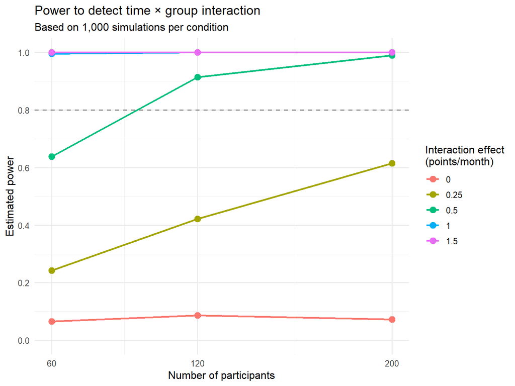

```r
ggplot(
  power_grid,
  aes(
    x = n_participants,
    y = power,
    colour = factor(b_time_gr_true)
  )
) +
  geom_hline(
    yintercept = 0.80,
    linetype = "dashed",
    colour = "grey50"
  ) +
  geom_line(linewidth = 1) +
  geom_point(size = 3) +
  scale_x_continuous(breaks = n_vals) +
  scale_y_continuous(
    limits = c(0, 1),
    breaks = seq(0, 1, 0.2)
  ) +
  labs(
    x = "Number of participants",
    y = "Estimated power",
    colour = "Interaction effect\n(points/month)",
    title = "Power to detect time × group interaction",
    subtitle = "Based on 1,000 simulations per condition"
  ) +
  theme_minimal(base_size = 12)
```

If the true intervention effect is 0.5 points/month, a study with 60 participants frequently fails to detect it, whereas 120 participants detects it in about 91% of simulated studies.

**Simulation summary** The simulation demonstrates how the ability to detect the time-by-intervention interaction depends on both sample size and the magnitude of the true intervention effect. Under the specified assumptions, an interaction of 0.25 points/month was difficult to detect even with 200 participants, whereas an interaction of 0.5 points/month reached 91.4% estimated power with 120 participants. Effects of 1.0 point/month or greater were detected in almost all simulated studies, even with 60 participants. These results illustrate that sample-size requirements depend strongly on the smallest intervention effect considered meaningful, as well as on the assumed variability in the outcome.

## Design implications

Based on these simulations, a study with N = 120 participants has high power to detect moderate intervention effects on the rate of change (≥ 0.5 points/month), but low power for very small effects (0.25 points/month). If the smallest substantively meaningful interaction is around 0.5 points/month, the current design (120 participants, three waves) is adequate. If smaller effects are of interest, either the sample size or the number of measurement occasions would need to be increased.

## Limitations

- All data are simulated with parameters chosen by the author, so power holds only under these assumptions.
- The data were generated with person-specific slopes (SD = 0.5), but the power model omits random slopes. Here the interaction SE changes by only about 1%, but with larger slope variation the test would become too optimistic.
- The design is balanced, with no dropout or missing data, equal spacing and normal errors.
- With 1,000 simulations per condition, each power estimate has Monte Carlo error of up to about ±1.5 percentage points.
- With three time points, individual differences in change are hard to detect, so the random-slope conclusion is weak.